# Clustering Analysis on ETF Trading

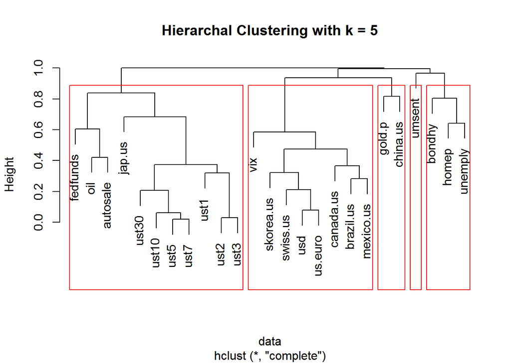

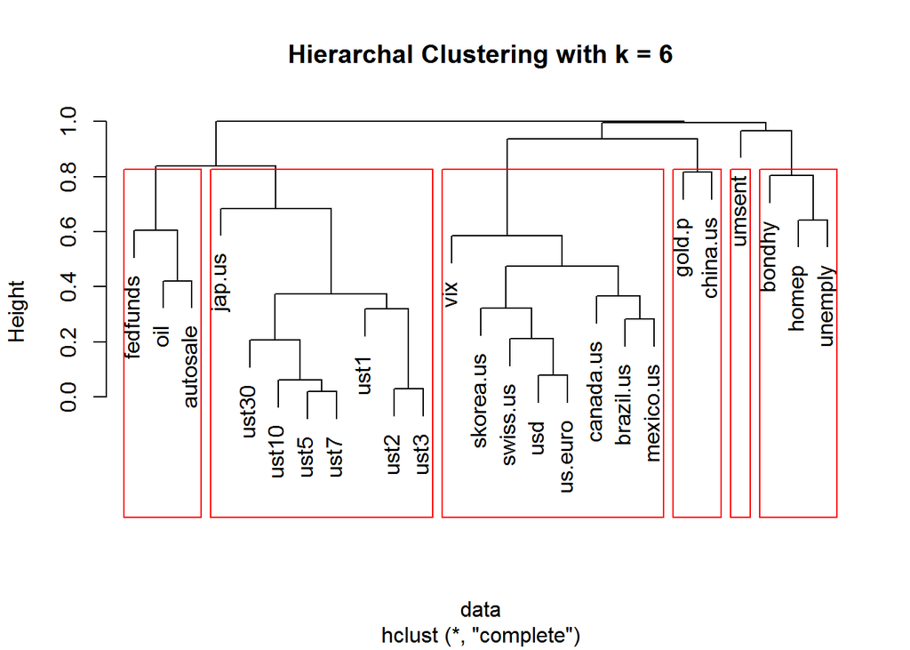

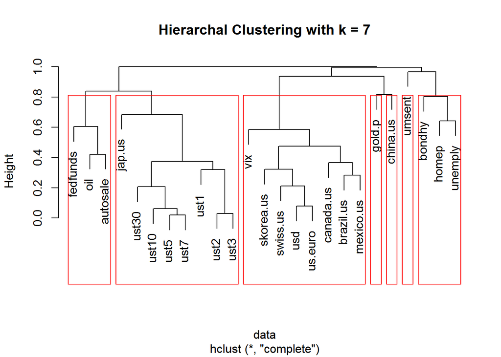

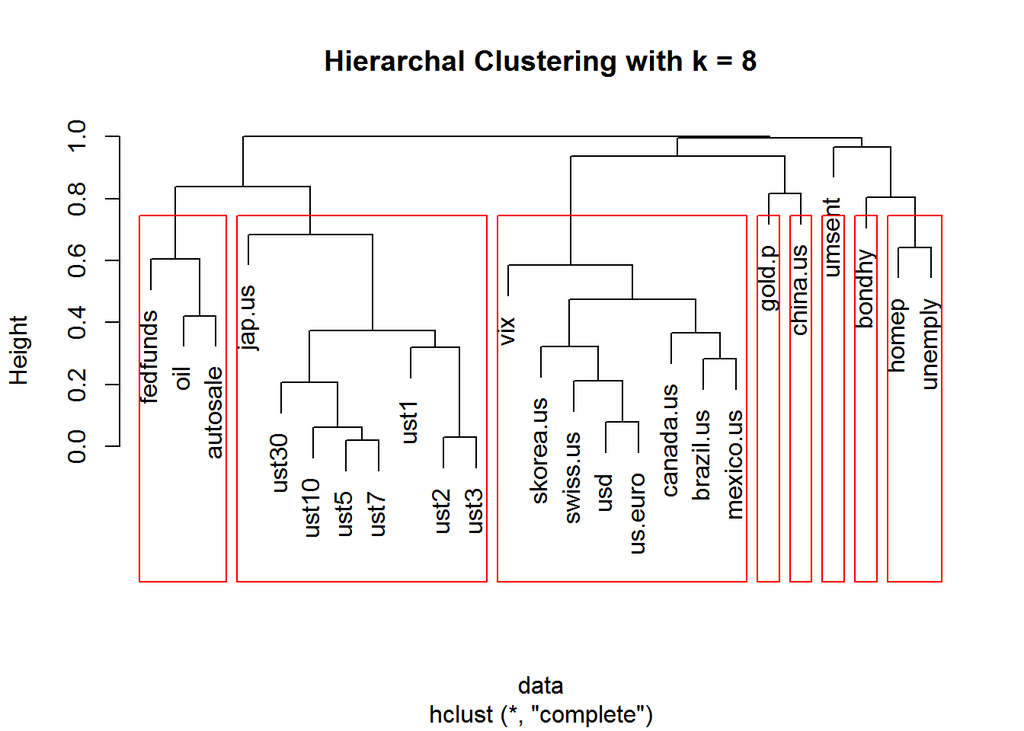

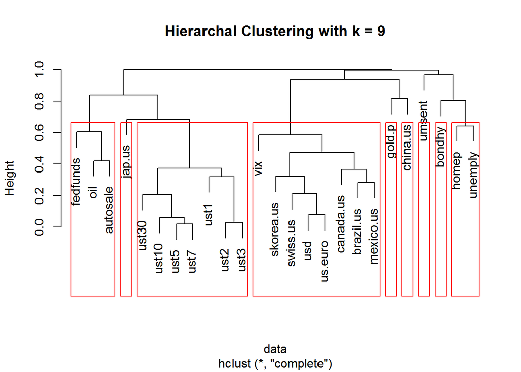

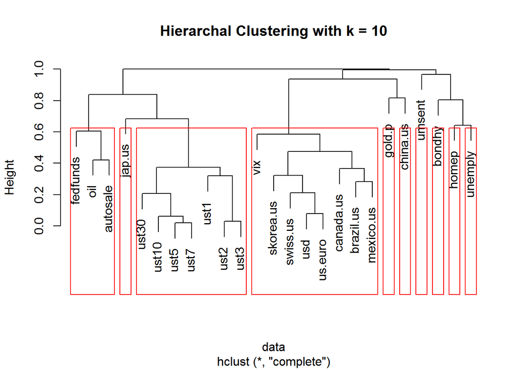

```r
test.hc(dist, 5, 10)
```

```r
# Selected Model (store ordered groups with their tags)
k = 10 ; k.out <- run.clustering(dist, k, "hc", max.elem.out = max.out)
```

```
## [1] Cluster 1 contents (up to 8) :gold.p
## [1] Cluster 2 contents (up to 8) :oil fedfunds autosale
## [1] Cluster 3 contents (up to 8) :usd vix brazil.us canada.us mexico.us skorea.us swiss.us us.euro
## [1] Cluster 4 contents (up to 8) :china.us
## [1] Cluster 5 contents (up to 8) :jap.us
## [1] Cluster 6 contents (up to 8) :umsent
## [1] Cluster 7 contents (up to 8) :homep
## [1] Cluster 8 contents (up to 8) :unemply
## [1] Cluster 9 contents (up to 8) :bondhy
## [1] Cluster 10 contents (up to 8) :ust1 ust2 ust3 ust5 ust7 ust10 ust30
```

```r
cluster.h.c <- k.out[[2]]

save(cluster.k.d, cluster.k.c, cluster.h.d, cluster.h.c, file = "FE582_ProjectClusters.RData")
```

- (3.4): The Hierarchal Clustering analysis for correlated data showed us good results. As explained before, we pick the best clusters and prune the tree to identify the the optimal analysis. After selecting 5 - 10 prunes, we selected 10 as the best model. There are many free floating compoenents here, as well clear groupings of FX rates and USt rates. This analysis is good and we now move on to putting these subsets to the test.
4. Create Final Data Subsets for each ETF based on the 4 classification methods (4x10 models)

```r
# Create Clustered Data Sets across cluster groupings and within cluster correlation testing
clustered.data.all <- create.subs(obs.cor.all, cluster.k.d, cluster.h.d, cluster.k.c, cluster.h.c, etf.class.train)
```

```
## [1] -------------------------------------------------------------------------
## [1] Step 1: Data Adjustments for input paramaters...
## [1] Step 2: Attaching Cluster Tags...
## [1] Step 3: Filtering parameter lists by best parameter and attempt colinearity removal by cluster...
## [1] Step 4: Creating Final Data Output list (List with data sets)...
```

```r
clustered.data.sub <- create.subs(obs.cor.sub, cluster.k.d, cluster.h.d, cluster.k.c, cluster.h.c, etf.class.train)
```

```
## [1] -------------------------------------------------------------------------
## [1] Step 1: Data Adjustments for input paramaters...
## [1] Step 2: Attaching Cluster Tags...
## [1] Step 3: Filtering parameter lists by best parameter and attempt colinearity removal by cluster...
## [1] Step 4: Creating Final Data Output list (List with data sets)...
```

```r
print(noquote(paste("Data filtered per Cluster Technique per ETF i.e. (",paste(names(clustered.data.sub$s.energy$kd),collapse=", "),")",sep="")))
```

```
## [1] Data filtered per Cluster Technique per ETF i.e. (s.energy, s.energymove, canada.us, oil, vix, ust10)
```

```r
save(clustered.data.all, clustered.data.sub, file = "FE582_ClusteredDataSets.RData")
```

- (4): After the 4 clustering analyses are complete, the data needs to be filtered a second time and aggregated into a large data structure where for each ETF we store the relevant ETF value, classification factor and indicator data sets. The filtering is conducted by taking each cluster group for the current ETF and cluster technique used and selecting the most highly correlated elements from each seperate cluster. Then, if there are remianing memebrs in the same cluster, they are evaluated for their correlation with the chosen elem. If their correlation < 0.5, we keep these elems as well (le thn 50% correlation is the maximum threshold that is reasonabl allowed in Collinarity and redundancy testing that we have reserahced. These are done grouped by the cluster tags (clusters defined in analysis) so that we can build models across the ETFs awith repsect to the subsets dictated by the clusters.
- All data analysis is complete for model consruction. We will now build, predict and backtest our models to see how our hypothsis holds.

(5.1) Build Multi-Variate Linear Regression Models

```r
# Build the Linear Models
models.lm.list.all <- build.lm(clustered.data.all, etf.class.train, sum = FALSE)
models.lm.list.sub <- build.lm(clustered.data.sub, etf.class.train, sum = FALSE)

# Glimpse at models
summary(models.lm.list.sub$s.hc$hd)
```

```
##
## Call:
## lm(formula = s.hc ~ vix + mexico.us, data = temp2)
##
## Residuals:
##      Min       1Q   Median       3Q      Max
## -0.11742 -0.01176  0.00269  0.01505  0.04740
##
## Coefficients:
##              Estimate Std. Error t value Pr(>|t|)
## (Intercept)  0.011184   0.003221   3.472  0.00089 ***
## vix         -0.102522   0.020100  -5.101 2.77e-06 ***
## mexico.us   -0.441283   0.111082  -3.973  0.00017 ***
## ---
## Signif. codes:  0 '***' 0.001 '**' 0.01 '*' 0.05 '.' 0.1 ' ' 1
##
## Residual standard error: 0.02728 on 70 degrees of freedom
## Multiple R-squared:  0.6098, Adjusted R-squared:  0.5987
## F-statistic:  54.7 on 2 and 70 DF,  p-value: 4.953e-15
```

```r
summary(models.lm.list.all$s.hc$hd)
```

```
##
## Call:
## lm(formula = s.hc ~ vix + mexico.us + ust1, data = temp2)
##
## Residuals:
##      Min       1Q   Median       3Q      Max
## -0.09667 -0.01076  0.00308  0.01489  0.05123
##
## Coefficients:
##              Estimate Std. Error t value Pr(>|t|)
## (Intercept)  0.009515   0.003211   2.963  0.00417 **
## vix         -0.096304   0.019700  -4.889 6.36e-06 ***
## mexico.us   -0.508177   0.111702  -4.549 2.24e-05 ***
## ust1        -0.046211   0.020121  -2.297  0.02468 *
## ---
## Signif. codes:  0 '***' 0.001 '**' 0.01 '*' 0.05 '.' 0.1 ' ' 1
##
## Residual standard error: 0.02648 on 69 degrees of freedom
## Multiple R-squared:  0.6375, Adjusted R-squared:  0.6218
## F-statistic: 40.45 on 3 and 69 DF,  p-value: 3.367e-15
```

```r
save(models.lm.list.all, models.lm.list.sub, file = "FE582_LinearModels.RData")
```